# A propos

# Bienvenue sur la page de Pierre Brasseur

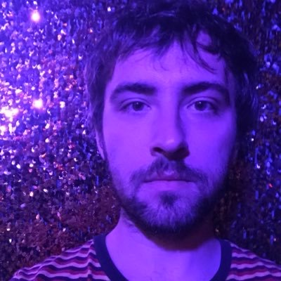

Pierre Brasseur est membre du centre de recherche [METICES](https://metices.phisoc.ulb.be/corps-academique/brasseur-pierre). Depuis septembre 2024, il occupe le poste de professeur à l’Université Libre de Bruxelles, où il se consacre à l’enseignement et à la recherche en sociologie, avec un focus particulier sur la sexualité, le sexe, le handicap et la santé.

Avant son arrivée à l’ULB, il a joué un rôle significatif au sein de l’Association française de sociologie, notamment en dirigeant le groupe « [éthique professionnelle](https://afs-socio.fr/groupe-ethique-professionnelle/) » et en coordonnant les actions contre les [violences sexistes et sexuelles](https://afs-socio.fr/charte-de-lassociation-francaise-de-sociologie-pour-lutter-contre-les-violences-sexistes-et-sexuelles/). De plus, il a assumé la responsabilité du réseau thématique « [recherches en sciences sociales sur la sexualité](https://afs-socio.fr/rt/rt28/) ».

Les recherches de Pierre Brasseur se concentrent sur divers domaines. Il s’intéresse aux politiques et à la régulation du genre et de la sexualité au travail, ainsi qu’à la discrimination liée au sexe, à la sexualité, au handicap et à l’état de santé. Il explore aussi la sociologie des lieux d’enfermement, l’éducation à la sexualité et à l’égalité des sexes, la sociologie de l’enfance et les méthodes de recherche en terrains sensibles.

En plus de son enseignement et de ses recherches, Pierre Brasseur supervise et évalue des recherches en sociologie, principalement axées sur le handicap, la santé sexuelle et la sociologie du travail.